# BPB3: BayesPI-BAR version 3 package User Guide

# Demo2:

# Ranking the effect of sequence variation on TF binding based on clustered PWMs

demo2_67snps_cluster4pwm

## Aim

Demo2 is to rank the effect of sequence variation (e.g., the 67 known regulatory SNPs) on TF binding but based on the clustered PWMs.

More specifically, there are two types of rankings based on the clustered PWMs:

1. To assess the TF binding affinity changes by only using the clustered PWMs, in which both foreground and background TF binding affinity changes are calculated based on the clustered PWs (C1_full).
2. To predict significant TF binding affinity changes by using a two-level approach: in the first level, a calculation of foreground TF binging affinity changes is based on the clustered PWMs; in the second level, the top N ranked clustered PWMs from the first level will be used for a comparison between the foreground and the background TF binding affinity changes due to sequence variants (C1fC2_N).

Usually, the (C1_full) approach is much faster than the (C1fC2_N) method because the number of clustered PWMs is far less than the total number of PWMs. Nevertheless, (C1_full) only can predict a result to a specific cluster of PWMs, but (C1fC2_N) can pinpoint a result to individual TF such as Demo1.

Often, (C1fC2_N) provides similar prediction accuracy as that obtained by the full PWMs such as Demo1, but it will use much less CPU time, because the total number of PWMs selected for the second-level calculation is far less than the full PWMs. In Demo2, there is an illustration of both types of rankings (C1_full and C1fC2_N) based on the clustered PWMs, which requires less running time than Demo1.

**Clustered PWMs:** The clustered PWMs are generated by a Python package Affinity Based Clustering for Position Weight Matrices (abc4pwm), by which the PWMs from multiple sources are able to be efficiently classed into representative clusters and and filtered out incorrectly clustered PWMs.

More descriptions of PWMs clustering are described by [Omer A. et al, 2022](https://bmcbioinformatics.biomedcentral.com/track/pdf/10.1186/s12859-022-04615-z.pdf).

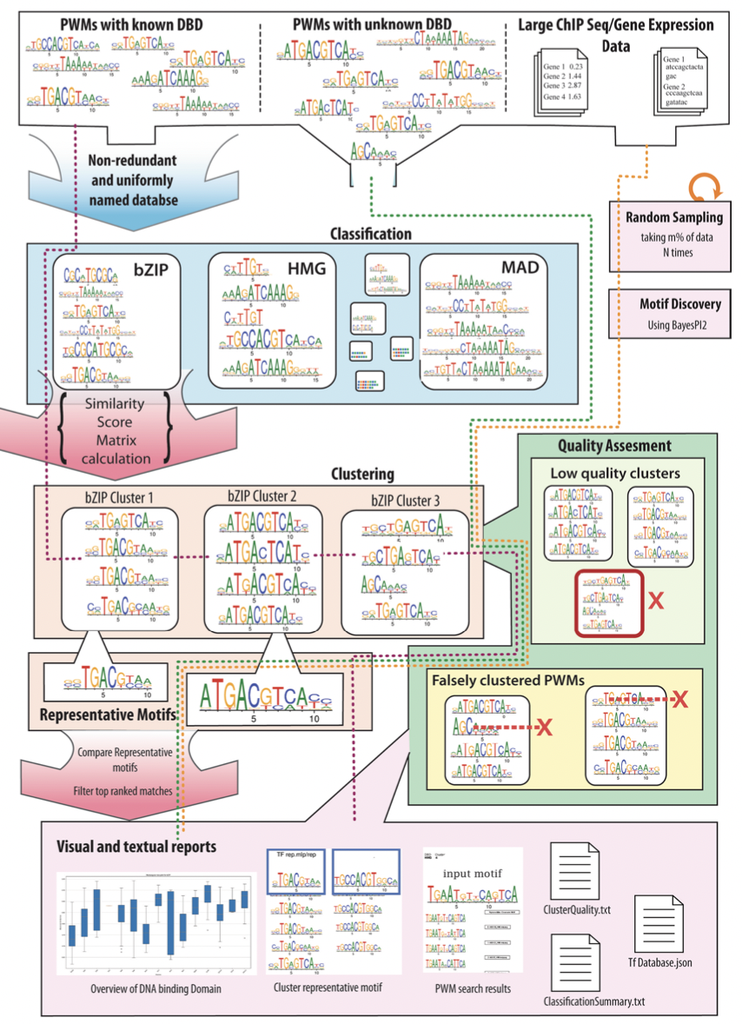

An overview of abc4pwm workflow for PWMs clustering

## Run job 1.

## Ranking the effect of sequence variation on TF binding based on clustered PWMs

**data input**

1. final_demo_data/demo1_67snps/in/snps_alt.fasta (same as demo1)
2. final_demo_data/demo1_67snps/in/snps_ref.fasta (same as demo1)
3. reference PWMs in clustered format, including 1772 PWMs, imported from abc4pwm module
   - abc4pwm_quality_assessed_out_seed5
   - abc4pwm_uncertain_pwms

**data output**

Table of SNPs ID in output:

[output not shown]

Table of TFs ranking in output:

| change | rank | file_name | score_pca | mean_ddba |
| --- | --- | --- | --- | --- |
| Positive | 1 | SP1_known6_from_SP1_5_from_Sp1_transfac_M00933-NonO_domain_factors.mlp | 0.1368920 | 0.0345481 |
| Positive | 2 | SP1_known5_from_SP1_4_from_Sp1_transfac_M00932-NonO_domain_factors.mlp | 0.1043255 | 0.0220307 |
| Positive | 3 | 14_MAZ_1_from_MAZ_transfac_M00649-C2H2_ZF.mlp | 0.1005619 | 0.0308141 |
| Positive | 4 | 15_EGR1_known4_from_EGR_2_from_KROX_transfac_M00982-C2H2_ZF.mlp | 0.0980301 | 0.0193677 |
| Positive | 5 | SP1_known2_from_SP1_2_from_Sp1_transfac_M00196-NonO_domain_factors.mlp | 0.0841727 | 0.0172808 |
| Positive | 6 | 22_MZF1_4_from_MZF1:5-13_jaspar_MA0057.1-C2H2_ZF.mlp | 0.0799525 | 0.0283515 |
| Positive | 7 | SP1_known4_from_SP1_3_from_Sp1_transfac_M00931-NonO_domain_factors.mlp | 0.0726897 | 0.0172488 |
| Positive | 8 | SP1_known7_from_SP1_6_from_SP1_jaspar_MA0079.2-NonO_domain_factors.mlp | 0.0691712 | 0.0162935 |
| Positive | 9 | 0_EGR4_2_from_EGR4_jolma_DBD_M8-C2H2_ZF.mlp | 0.0657235 | 0.0128093 |
| Positive | 10 | SP1_known9_from_SP3_2_from_SP3_jolma_DBD_M30-NonO_domain_factors.mlp | 0.0626507 | 0.0149608 |

**Job script**

```bash
#!/bin/csh
#Job name:
#SBATCH --job-name=demo2-bpb3-clust
#
# Project:
#SBATCH --account=nn4605k
#
# Wall clock limit:
#SBATCH --time=12:00:00
#
# Max memory usage:
#SBATCH --mem-per-cpu=10G --partition=bigmem
#
# Number of cores:
#SBATCH --cpus-per-task=12

#run 67 snp demos with abc4pwm clustered PWMs
python bpb3_clustered_pwms.py
```

**Main process**  
The main processes are stored in Slurm file, example:

```
['IL4_Oct-1|LOSS', 'LEP_Sp1|GAIN', 'ALOX15_SPI1|GAIN', 'AGTRL1_SP1|GAIN']
Calculating delta-dbA values...
Integrating delta-dbA values across chemical potentials using mean_ddba ...
Integrating delta-dbA values across chemical potentials using pca ...
Computing PWM rankings for each variant...
```

**CPU requirement**(C1_full and C1fC2_N together) The running time is less than demo1.

- MaxRSS: 192 MB
- Running time: 26 min

## Run Job 2.

## Check predition accuracy

- check_accuracy4clusteredPwm.sh

Run job 2 in terminal, set the parameter of predicted top TFs number as 10:

```bash
bash check_accuracy4clusteredPwm.sh 10
```

The accuracy in total is the same at 77.6% by both C1_full and C1fC2_N methods. The accuracy is also very similar as in demo1. The running process information is displayed in screen:

[output not shown]

## Python code

- bpb3_clustered_pwms.py

```python
#this file is usded to evaluate bpb3 with clustered pwms by using bpb3 command lines
import os
import glob
from bpb3.script.script_high.other import common
import time

###########Setup main Path ################
#snp Data Input folder
source_data_folder= os.path.abspath('../../final_demo_data/demo1_67snps/in')
ref_seq = os.path.join(source_data_folder,"snps_ref.fasta")
alt_seq = os.path.join(source_data_folder,"snps_alt.fasta")

#Project Output path
project_name='demo2_67snps_cluster4pwm'

out_data_folder= os.path.abspath("../../final_demo_data/demo2_67snps_cluster4pwm")
common.check_folder(out_data_folder)

out_project_folder=os.path.join(out_data_folder, project_name)
common.check_folder(out_project_folder)

logging =common.setup_logger(out_project_folder,project_name, time.time())


# 1. Generate tempary pwms based on clustered and uncertain clustered PWMs from abc4pwm############
#here file folers 'abc4pwm_quality_assessed_out_seed5' and 'abc4pwm_uncertain_pwms' contain clustered pwms from abc4pwm by using 1772 pwms
#
in_clustered_pwms_path=out_data_folder
in_clustered_pwms_folder_name='abc4pwm_quality_assessed_out_seed5'
in_uncertain_pwms_folder_name='abc4pwm_uncertain_pwms'
out_tmp_pwms_folder_name='tmp_pwm'

#make pwm input files for clustred PWMs in bpb3 package
if True:
 logging.info("Make clustered PWMs input files for bpb3 ")
 cmd='bpb3 make_cluster4pwm --in_pwm_path ' + in_clustered_pwms_path +  \
        ' --in_clustered_pwm_folder ' +  in_clustered_pwms_folder_name + \
    ' --out_file_folder ' + out_tmp_pwms_folder_name + \
    ' --in_uncertain_pwm_folder ' + in_uncertain_pwms_folder_name

 result_code=os.system(cmd)
 if result_code != 0:
      print("bpb3 make_cluster4pwm failed. See message in the console to find what went wrong.")
      exit(1)
 logging.info('Export at %s', os.path.join(in_clustered_pwms_path, out_tmp_pwms_folder_name))

######### Setup parameters in clustered PWMs for bayespi-bar3###################
# folder with PWM models for TF binding affinity, here we use clustered PWM first
pwm_folder=os.path.join(out_data_folder,out_tmp_pwms_folder_name)

# output folders  for bayespi-bar
foreground_folder = os.path.join(out_project_folder ,"foreground")
common.check_folder(foreground_folder)

block_res_folder = os.path.join(foreground_folder,"test_seq")
common.check_folder(block_res_folder)

# BayesPI-BAR options
# chemical potentials to use
chemical_potentials = "none -10 -13 -15 -18 -20"

# sequence shuffling iterations for dbA calculation
shuffling_iterations = 10000
random_seed=1

#Parallel option path
parallel_options_file = os.path.abspath(os.path.join(os.path.dirname(__file__), "parallel_options.txt"))

# max rank of a PWM file in the foreground results to include in ranking TFs
max_ranking_for_TF = 50
top_ranked_TF_from_clusteredPWM=20
isChangePWMname=True
start_from_integration=False
export_top_ranked_TF=30
clean_tmp_files=False

#################START do bpb3 BayesPI-BAR on clustered PWMS ############
#2. run bpb3 on clustered PWMs - first level analysis
if True:
 logging.info("Pipeline parameters:")
 logging.info("\tBayesPI-BAR options: %d sequence shuffling iterations, %d chemical potentials: %s",
                 shuffling_iterations, len(chemical_potentials.split(" ")), chemical_potentials)

 cmd="bpb3 bayespi_bar" + \
                    " --reference_sequences " + ref_seq +\
                                " --alternate_sequences " + alt_seq +\
                                " --pwm_folder " + pwm_folder +\
                                " --chemical_potentials " + chemical_potentials +\
                                " --iterations " + str(shuffling_iterations) +\
                                " --result_folder " + block_res_folder +\
                                " --max_rank " + str(max_ranking_for_TF) +\
                                " --seed " + str(random_seed) + \
                                " --reuse_output" \
                                " @" + parallel_options_file
 result_code = os.system(cmd)
 if result_code != 0:
      logging.info("BayesPI-BAR failed. See message in the console to find what went wrong.")
      exit(1)
 logging.info('Export at %s', block_res_folder )

#collect all mlp in ranking results
#3. perform bayespi_bar on the selected pwms from the top ranked # TF from clusters of PWMs - second level analysis
output_file_folder='new_test_sep'
if True:
 cmd= 'bpb3 bpb3selectedPWM --cluster_out_path '  + out_data_folder + \
    ' --bpb3_out_path ' + os.path.join(block_res_folder,'rankings')  + \
    ' --in_fileString4clustered_pwm ' + in_clustered_pwms_folder_name  + \
    ' --project_name ' + 'selected_pwm_from_cluster4rank_top' + str(top_ranked_TF_from_clusteredPWM) + \
    ' --output_folder ' + output_file_folder  + \
    ' --in_fileString4uncertain_pwm '+ in_uncertain_pwms_folder_name + \
    ' --in_separateString4file '+ str("\'~\'") + \
    ' --in_topRank_cutoff ' + str(top_ranked_TF_from_clusteredPWM) + \
    ' --in_seq_ref_file ' + ref_seq +\
    ' --in_seq_alt_file ' + alt_seq +\
    ' --iterations ' + str(shuffling_iterations) +  \
    ' --max_rank ' + str(export_top_ranked_TF) + \
    ' --seed ' + str(random_seed) + \
    ' --chemical_potentials ' + chemical_potentials +\
        ' --change_pwm_name ' * isChangePWMname + \
        ' --clean_tmp ' * clean_tmp_files + \
        ' --skip_dba_calculation ' * start_from_integration + \
    ' --p_value_cutoff ' +'0.1' +  ' --integration pca' + \
         ' @' +  parallel_options_file
 result_code=os.system(cmd)
 if result_code !=0:
    logging.info("bpb3selectedPWM failed, see message in the console to find reason.")
    exit(1)
 logging.info('Export at %s ', out_data_folder )


if True:
 #6. clean temporary files
 logging.info("")
 logging.info("Remove temporary files in background or foreground calculations. ")
 foreground_folder1=os.path.join(out_data_folder, 'selected_pwm_from_cluster4rank_top' + str(top_ranked_TF_from_clusteredPWM), output_file_folder)
 background_folder= foreground_folder1
 background_pwm_folder=foreground_folder1
 print(foreground_folder1)
 result_code=os.system('bpb3 clean_tmp --background_out_file ' + background_folder +
                ' --foreground_out_file ' + foreground_folder1  +  ' --chemical_potentials ' + chemical_potentials  +
                ' --background_pwm_file ' + background_pwm_folder + ' --clean_both 1' )
 if result_code !=0:
   logging.info("Error in clean tmp ")
   exit(1)

 foreground_folder1=foreground_folder
 print(foreground_folder1)
 result_code=os.system('bpb3 clean_tmp --background_out_file ' + background_folder +
                ' --foreground_out_file ' + foreground_folder1  +  ' --chemical_potentials ' + chemical_potentials  +
                ' --background_pwm_file ' + background_pwm_folder + ' --clean_both 1' )
 if result_code !=0:
   logging.info("Error in clean tmp ")
   exit(1)

else:
 logging.info('Skip step 6: remove temporary file %s ', background_pwm_folder)
```